# Meta_analysis

## La Théorie Moderne du Portefeuille

*Réalisé par*: Aboulaala Maria

*Encadré par*: Mme.Ghizlane LAKHNATI

La gestion de portefeuille implique la valorisation d'un ensemble de titres financiers tout en respectant les contraintes réglementaires et contractuelles. Cela vise à minimiser la variance et donc le risque du portefeuille sans compromettre le rendement escompté. Dans ce contexte, il est essentiel d'exposer les modèles financiers fondamentaux qui sous-tendent la finance moderne. Ces modèles ont permis aux gestionnaires de portefeuille de comprendre les concepts d'évaluation des actifs financiers, de diversification et du compromis risque/rendement. Deux modèles clés à cet égard sont le Modèle d'Évaluation des Actifs Financiers (MEDAF) et la Théorie Moderne du Portefeuille (MPTL). Le Modèle d'Évaluation des Actifs Financiers (CAPM) est particulièrement pertinent, décrivant la relation entre le rendement attendu et le risque d'investissement dans un titre. Il établit que le rendement anticipé d'un titre est égal au rendement sans risque additionné d'une prime de risque liée à la volatilité du marché. En outre, la Théorie Moderne du Portefeuille définit le processus de sélection de titres visant à créer le portefeuille le plus efficient possible, caractérisé par un rendement maximal pour un niveau donné de risque.

## A- Téléchargement des packages :

```python
import numpy as np
import pandas as pd
import matplotlib.pyplot as plt
from arch.unitroot import ADF
import statsmodels.graphics.tsaplots as sgt
from scipy import stats
import pylab as pl
import math
import yfinance as yf
plt.style.use('fivethirtyeight')
import warnings
warnings.simplefilter('ignore')
```

## B- L'Implémentation des données :

Le tableau suivant présente notre jeu de données de cinq actions: AAPL, NKE, GOOGLE, AMZONE et SP500 pour la derrnière année:

```python
import yfinance as yf


tickers = ['AAPL', 'NKE', 'GOOGL', 'AMZN', 'SPY']
start_date = '2019-11-30'
end_date = '2020-11-30'

data = yf.download(tickers, start=start_date, end=end_date)['Adj Close']
```

```
[                       0%%                      ][*********************100%%**********************]  5 of 5 completed
```

```python
data.head()
```

| Date | AAPL | AMZN | GOOGL | NKE | SPY |
| --- | --- | --- | --- | --- | --- |
| 2019-12-02 | 64.338280 | 89.080002 | 64.443001 | 90.148468 | 292.384277 |
| 2019-12-03 | 63.191124 | 88.498001 | 64.737000 | 89.088608 | 290.423248 |
| 2019-12-04 | 63.748875 | 88.034500 | 65.946999 | 90.302643 | 292.215332 |
| 2019-12-05 | 64.684113 | 87.024002 | 66.348000 | 92.297142 | 292.740692 |
| 2019-12-06 | 65.933578 | 87.580002 | 66.969498 | 93.463043 | 295.414551 |

```python
data.isna().sum()
```

```
AAPL     0
AMZN     0
GOOGL    0
NKE      0
SPY      0
dtype: int64
```

```python
data.describe()
```

|  | AAPL | AMZN | GOOGL | NKE | SPY |
| --- | --- | --- | --- | --- | --- |
| count | 251.000000 | 251.000000 | 251.000000 | 251.000000 | 251.000000 |
| mean | 88.344027 | 127.936061 | 72.052197 | 99.445773 | 300.507748 |
| std | 20.212500 | 28.633410 | 7.644110 | 15.160862 | 27.578840 |
| min | 54.776802 | 83.830498 | 52.706501 | 60.677971 | 211.438660 |
| 25% | 71.224220 | 97.245499 | 67.578247 | 90.442410 | 287.592636 |
| 50% | 79.332008 | 123.699997 | 72.508003 | 96.584915 | 305.588135 |
| 75% | 110.764317 | 156.501244 | 75.932251 | 108.813145 | 319.132263 |
| max | 131.624329 | 176.572495 | 89.350998 | 131.577606 | 347.797455 |

## C- La Pré-étude des séries chronologiques :

### 1- L'évolution des actions :

```python
# data.plot(figsize = (15,5))
# plt.title("L'évolution des Actions", size = 30, color = "red")
# plt.show()
import plotly.graph_objects as go

fig = go.Figure()

for column in data.columns:
    fig.add_trace(go.Scatter(x=data.index, y=data[column], name=column))

fig.update_layout(title="L'évolution des Actions", xaxis_title="Date", yaxis_title="Valeur", showlegend=True)
fig.show()
```

[output not shown]

On remarque que les séries chronologiques des trois actions AAPL, NKE et SP500 sont aussi non stationnaire, non saisonnière, mais elles ont une tendance haussière.

### 2- Etude de l'autocorrélaation, et la normalité :

- Test de Dickey-Fuller : On a testé la stationnarité de toutes les séries chronologiques avec le test de Dickey-Fuller et on obtient une p-value supérieure à 5% pour toutes les actions donc les séries chronologiques des prix sont non stationnaires. Donc il faut calculer les log rentabiltés pour rendre les séries stationnaire.

```python
data.head()
```

| Date | AAPL | AMZN | GOOGL | NKE | SPY |
| --- | --- | --- | --- | --- | --- |
| 2019-12-02 | 64.338280 | 89.080002 | 64.443001 | 90.148468 | 292.384277 |
| 2019-12-03 | 63.191124 | 88.498001 | 64.737000 | 89.088608 | 290.423248 |
| 2019-12-04 | 63.748875 | 88.034500 | 65.946999 | 90.302643 | 292.215332 |
| 2019-12-05 | 64.684113 | 87.024002 | 66.348000 | 92.297142 | 292.740692 |
| 2019-12-06 | 65.933578 | 87.580002 | 66.969498 | 93.463043 | 295.414551 |

```python
from arch.unitroot import ADF
actions = ["AAPL","NKE","GOOGL","AMZN","SPY"]
for i in actions:
    adf = ADF(data[i])
    print(adf.summary().as_text())
```

```
   Augmented Dickey-Fuller Results
=====================================
Test Statistic                 -0.763
P-value                         0.830
Lags                                1
-------------------------------------

Trend: Constant
Critical Values: -3.46 (1%), -2.87 (5%), -2.57 (10%)
Null Hypothesis: The process contains a unit root.
Alternative Hypothesis: The process is weakly stationary.
   Augmented Dickey-Fuller Results
=====================================
Test Statistic                 -0.355
P-value                         0.917
Lags                                0
-------------------------------------

Trend: Constant
Critical Values: -3.46 (1%), -2.87 (5%), -2.57 (10%)
Null Hypothesis: The process contains a unit root.
Alternative Hypothesis: The process is weakly stationary.
   Augmented Dickey-Fuller Results
=====================================
Test Statistic                 -1.251
P-value                         0.651
Lags                                9
-------------------------------------

Trend: Constant
Critical Values: -3.46 (1%), -2.87 (5%), -2.57 (10%)
Null Hypothesis: The process contains a unit root.
Alternative Hypothesis: The process is weakly stationary.
   Augmented Dickey-Fuller Results
=====================================
Test Statistic                 -1.023
P-value                         0.745
Lags                                3
-------------------------------------

Trend: Constant
Critical Values: -3.46 (1%), -2.87 (5%), -2.57 (10%)
Null Hypothesis: The process contains a unit root.
Alternative Hypothesis: The process is weakly stationary.
   Augmented Dickey-Fuller Results
=====================================
Test Statistic                 -1.467
P-value                         0.550
Lags                                9
-------------------------------------

Trend: Constant
Critical Values: -3.46 (1%), -2.87 (5%), -2.57 (10%)
Null Hypothesis: The process contains a unit root.
Alternative Hypothesis: The process is weakly stationary.
```

-Les graphiques d'autocorrélation (ACF) et de corrélation partielle (PACF) :

-> En analysant les graphiques d'autocorrélation ci-dessous, on observe que les retards (lags) présentent des valeurs significativement différentes de zéro au seuil de 5%.

-> En examinant les graphiques de corrélation partielle ci-dessous, on constate que certains retards ne se situent pas dans l'intervalle de confiance, indiquant ainsi que ces retards sont significativement différents de zéro au seuil de 5%. Par conséquent, une autocorrélation entre les observations des cinq séries est établie.

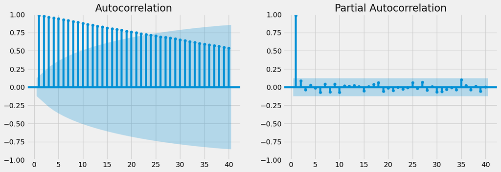

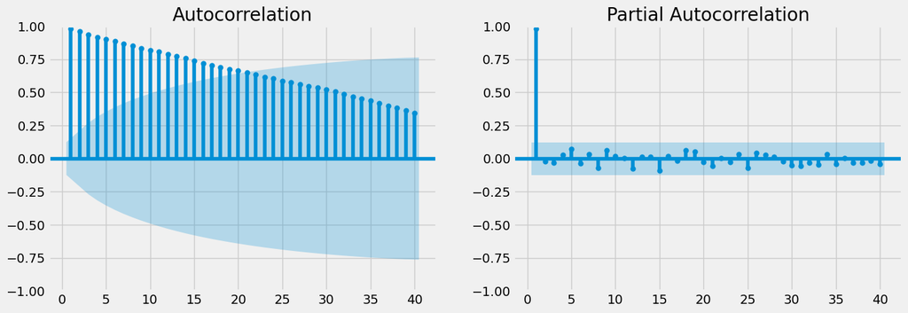

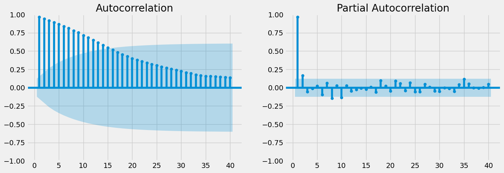

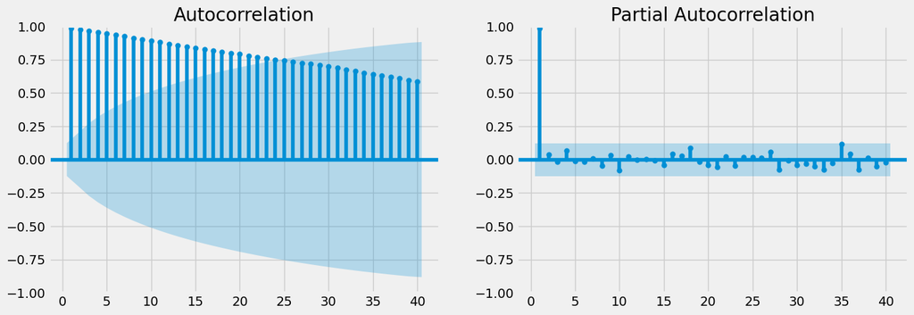

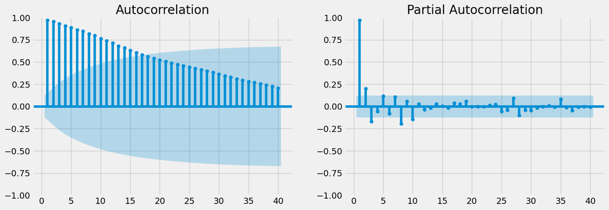

```python
for i in actions:
    f ,axes=plt.subplots(1,2,figsize=(15,5))
    sgt.plot_acf(data[i],lags = 40 ,zero = False,ax=axes[0])
    sgt.plot_pacf(data[i],lags = 40,zero = False,ax=axes[1])
    plt.show()
```

- La Distribution Normale et le test de Shapiro:

D'après les graphes de la distribution normale suivants, on remarque bien que les prix des actions AAPL, NKE, GOOGLE, AMZN et SP500 ne sont pas normales.

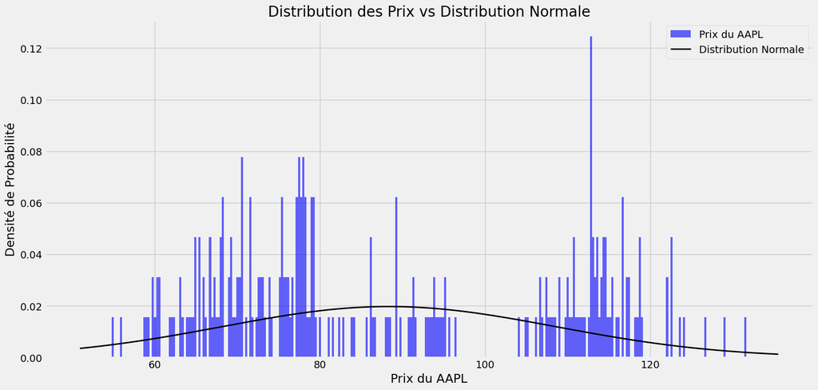

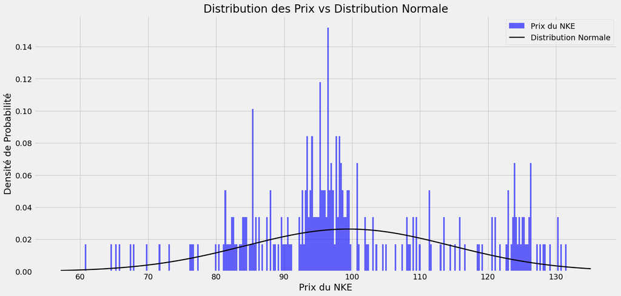

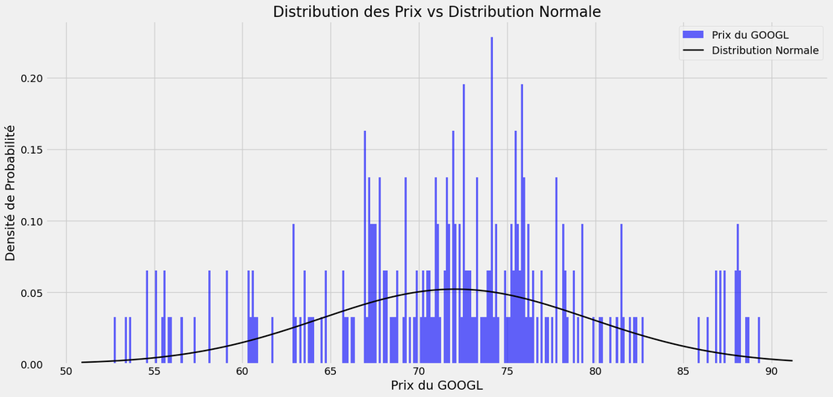

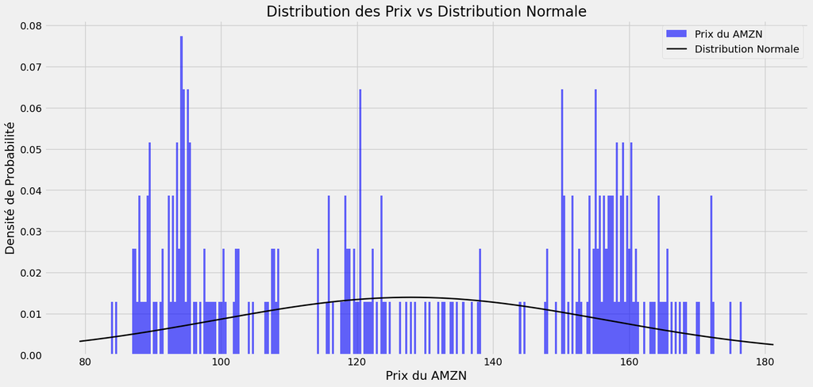

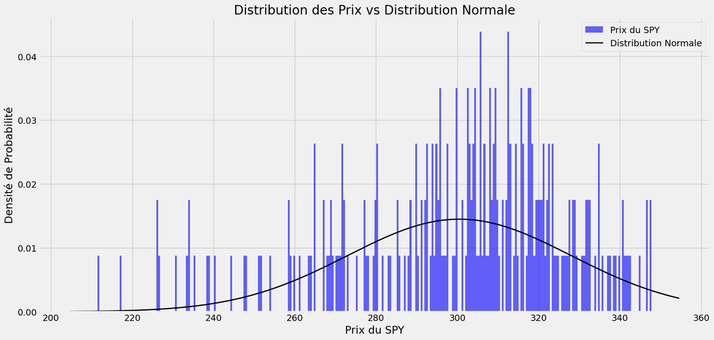

```python
from scipy.stats import norm

for ticker in actions:
    prices = data[ticker]

    # Plot histogram
    plt.figure(figsize=(17, 8))
    plt.hist(prices, bins=300, density=True, alpha=0.6, color='b', label=f'Prix du {ticker}')

    # Generate a normal distribution with the same mean and standard deviation
    mu, std = np.mean(prices), np.std(prices)
    xmin, xmax = plt.xlim()
    x = np.linspace(xmin, xmax, 300)
    p = norm.pdf(x, mu, std)

    # Plot the normal distribution
    plt.plot(x, p, 'k', linewidth=2, label='Distribution Normale')

    # Add legend, title, and axis labels
    plt.title('Distribution des Prix vs Distribution Normale')
    plt.xlabel(f'Prix du {ticker}')
    plt.ylabel('Densité de Probabilité')
    plt.legend()

    # Show the plot
plt.show()
```

```python
stats.shapiro(data)
```

```
ShapiroResult(statistic=0.7523528337478638, pvalue=9.665624313496145e-40)
```

### 3- les nouvelles séries stationnaires:

```python
test1 = data.pct_change().apply(lambda x: np.log(1+x))
test1 = test1.iloc[1:]
test1
```

| Date | AAPL | AMZN | GOOGL | NKE | SPY |
| --- | --- | --- | --- | --- | --- |
| 2019-12-03 | -0.017991 | -0.006555 | 0.004552 | -0.011826 | -0.006730 |
| 2019-12-04 | 0.008788 | -0.005251 | 0.018518 | 0.013535 | 0.006152 |
| 2019-12-05 | 0.014564 | -0.011545 | 0.006062 | 0.021846 | 0.001796 |
| 2019-12-06 | 0.019132 | 0.006369 | 0.009324 | 0.012553 | 0.009092 |
| 2019-12-09 | -0.014099 | -0.001194 | 0.002684 | -0.003822 | -0.003149 |
| ... | ... | ... | ... | ... | ... |
| 2020-11-20 | -0.011018 | -0.005669 | -0.012698 | 0.008079 | -0.006871 |
| 2020-11-23 | -0.030194 | -0.000326 | -0.005092 | 0.008611 | 0.005976 |
| 2020-11-24 | 0.011527 | 0.006328 | 0.020817 | 0.004240 | 0.015985 |
| 2020-11-25 | 0.007439 | 0.021263 | 0.000130 | 0.006217 | -0.001543 |
| 2020-11-27 | 0.004815 | 0.003219 | 0.012892 | -0.009563 | 0.002781 |

250 rows × 5 columns

```python
describe = test1.describe()
describe
```

|  | AAPL | AMZN | GOOGL | NKE | SPY |
| --- | --- | --- | --- | --- | --- |
| count | 250.000000 | 250.000000 | 250.000000 | 250.000000 | 250.000000 |
| mean | 0.002308 | 0.002337 | 0.001307 | 0.001474 | 0.000694 |
| std | 0.029244 | 0.024266 | 0.024298 | 0.026059 | 0.021296 |
| min | -0.137708 | -0.082535 | -0.123685 | -0.124053 | -0.115886 |
| 25% | -0.010176 | -0.010369 | -0.006618 | -0.009252 | -0.006160 |
| 50% | 0.002401 | 0.003135 | 0.003261 | 0.001500 | 0.002708 |
| 75% | 0.016756 | 0.014390 | 0.013424 | 0.013179 | 0.009358 |
| max | 0.113158 | 0.076308 | 0.088388 | 0.141284 | 0.086731 |

```python
import plotly.graph_objects as go

fig = go.Figure()

for column in test1.columns:
    fig.add_trace(go.Scatter(x=test1.index, y=test1[column], name=column))

fig.update_layout(title="L'évolution des rendements des actions", xaxis_title="Date", yaxis_title="Rendement", showlegend=True)
fig.show()
```

[output not shown]

Si on applique le test de Dickey Fuller sur les nouvelles séries, on obtient une p-value inférieure à 5% donc les nouvelles séries chronologiques des rendements sont stationnaires.

```python
actions = ["AAPL","NKE","GOOGL","AMZN","SPY"]
for i in actions:
    adf = ADF(test1[i])
    print(adf.summary().as_text())
```

```
   Augmented Dickey-Fuller Results
=====================================
Test Statistic                 -4.700
P-value                         0.000
Lags                                8
-------------------------------------

Trend: Constant
Critical Values: -3.46 (1%), -2.87 (5%), -2.57 (10%)
Null Hypothesis: The process contains a unit root.
Alternative Hypothesis: The process is weakly stationary.
   Augmented Dickey-Fuller Results
=====================================
Test Statistic                 -5.952
P-value                         0.000
Lags                                7
-------------------------------------

Trend: Constant
Critical Values: -3.46 (1%), -2.87 (5%), -2.57 (10%)
Null Hypothesis: The process contains a unit root.
Alternative Hypothesis: The process is weakly stationary.
   Augmented Dickey-Fuller Results
=====================================
Test Statistic                 -4.071
P-value                         0.001
Lags                                8
-------------------------------------

Trend: Constant
Critical Values: -3.46 (1%), -2.87 (5%), -2.57 (10%)
Null Hypothesis: The process contains a unit root.
Alternative Hypothesis: The process is weakly stationary.
   Augmented Dickey-Fuller Results
=====================================
Test Statistic                -18.193
P-value                         0.000
Lags                                0
-------------------------------------

Trend: Constant
Critical Values: -3.46 (1%), -2.87 (5%), -2.57 (10%)
Null Hypothesis: The process contains a unit root.
Alternative Hypothesis: The process is weakly stationary.
   Augmented Dickey-Fuller Results
=====================================
Test Statistic                 -4.094
P-value                         0.001
Lags                                8
-------------------------------------

Trend: Constant
Critical Values: -3.46 (1%), -2.87 (5%), -2.57 (10%)
Null Hypothesis: The process contains a unit root.
Alternative Hypothesis: The process is weakly stationary.
```

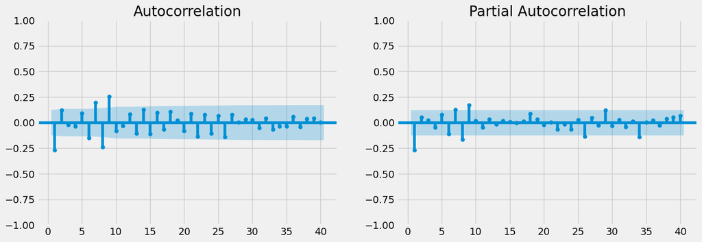

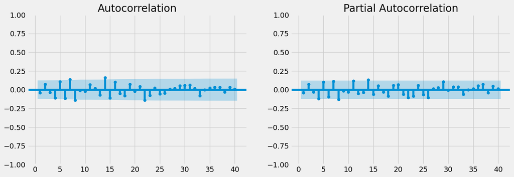

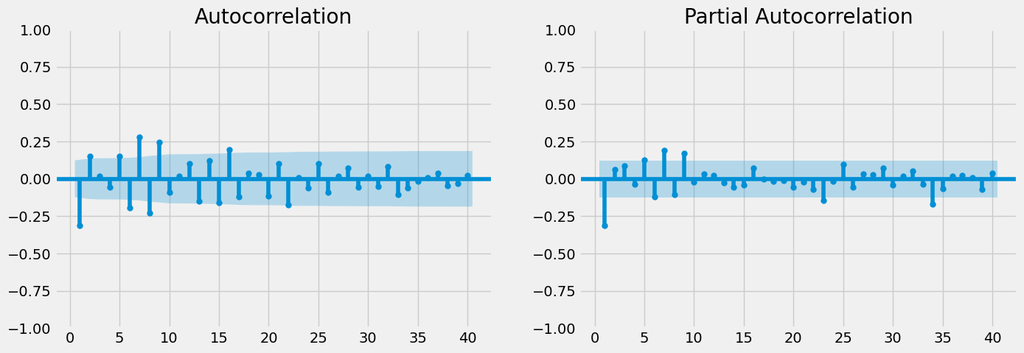

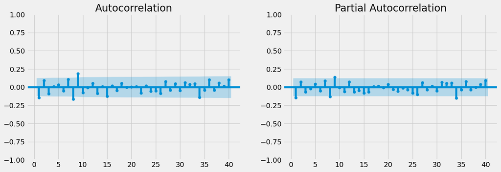

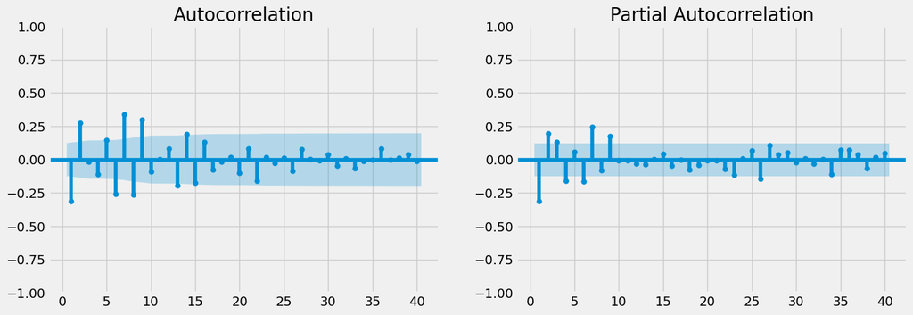

```python
for i in actions:
    f,axes=plt.subplots(1,2,figsize=(15,5))
    sgt.plot_acf(test1[i],lags = 40 ,zero = False,ax=axes[0])
    sgt.plot_pacf(test1[i],lags = 40,zero = False,ax=axes[1])
    plt.show()
```

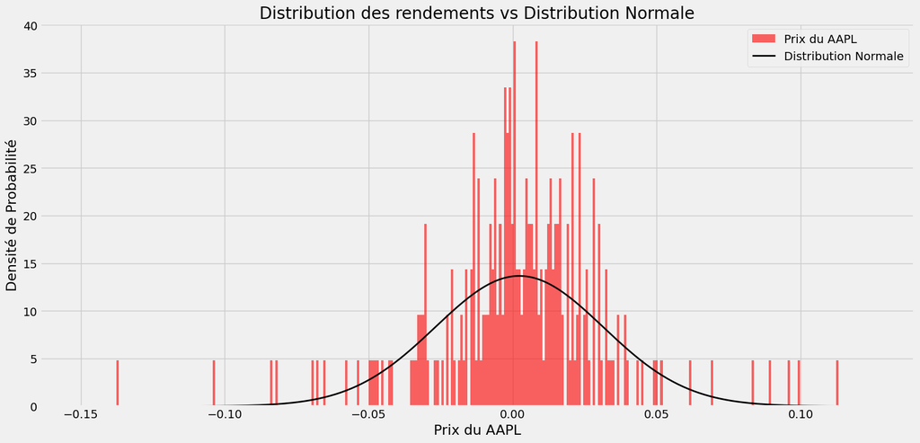

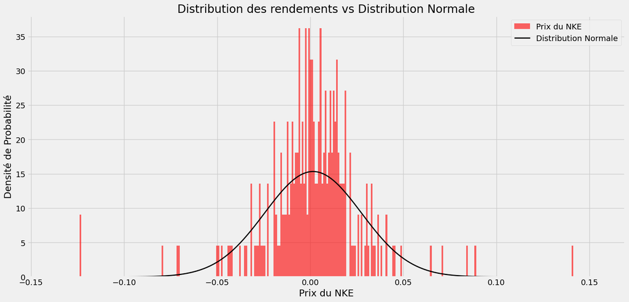

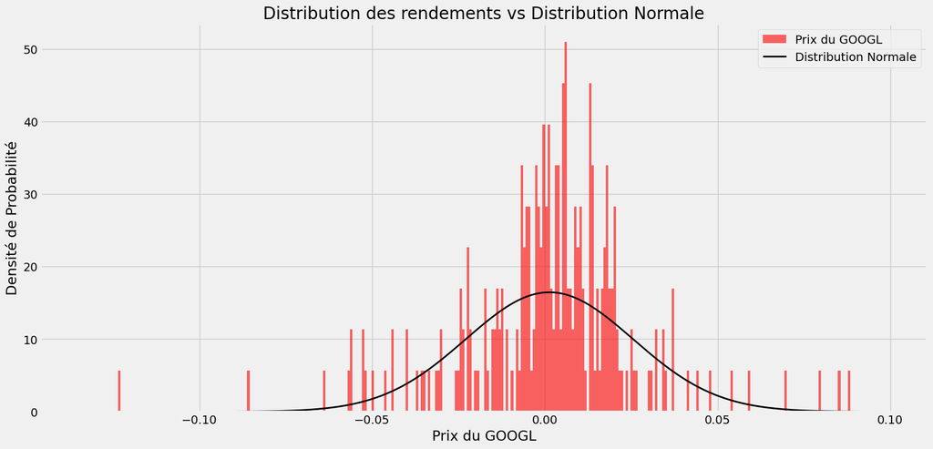

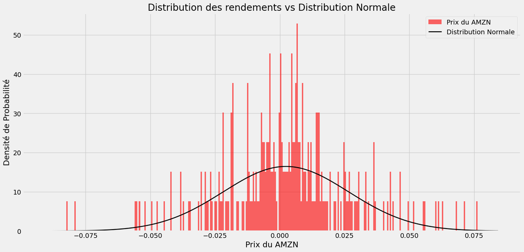

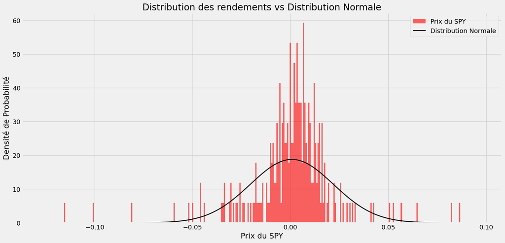

```python
for ticker in actions:
    prices = test1[ticker]

    # Plot histogram
    plt.figure(figsize=(17, 8))
    plt.hist(prices, bins=300, density=True, alpha=0.6, color='r', label=f'Prix du {ticker}')

    # Generate a normal distribution with the same mean and standard deviation
    mu, std = np.mean(prices), np.std(prices)
    xmin, xmax = plt.xlim()
    x = np.linspace(xmin, xmax, 300)
    p = norm.pdf(x, mu, std)

    # Plot the normal distribution
    plt.plot(x, p, 'k', linewidth=2, label='Distribution Normale')

    # Add legend, title, and axis labels
    plt.title('Distribution des rendements vs Distribution Normale')
    plt.xlabel(f'Prix du {ticker}')
    plt.ylabel('Densité de Probabilité')
    plt.legend()

    # Show the plot
plt.show()
```

On applique le test de normalité Shapiro sur les nouvelles séries stationnaires qui donne une p-value inférieur à 5% donc on a encore une absence de la normalité.

```python
stats.shapiro(test1)
```

```
ShapiroResult(statistic=0.9214699268341064, pvalue=5.369523746349757e-25)
```

- La covariance:

les coefficients de covariance sont tous positifs ce qui montre la variation des actions dans le même sens.

```python
cov_matrix = test1.cov()
cov_matrix
```

|  | AAPL | AMZN | GOOGL | NKE | SPY |
| --- | --- | --- | --- | --- | --- |
| AAPL | 0.000855 | 0.000502 | 0.000544 | 0.000476 | 0.000522 |
| AMZN | 0.000502 | 0.000589 | 0.000401 | 0.000251 | 0.000318 |
| GOOGL | 0.000544 | 0.000401 | 0.000590 | 0.000407 | 0.000445 |
| NKE | 0.000476 | 0.000251 | 0.000407 | 0.000679 | 0.000442 |
| SPY | 0.000522 | 0.000318 | 0.000445 | 0.000442 | 0.000454 |

- La matrice de Corrélation:

la matrice de corrélation suivante montre que les coefficients entre les actions sont supérieurs à 39% alors il existe une relation linéaire positive entre les actions.

```python
corr_matrix = test1.corr()
corr_matrix
```

|  | AAPL | AMZN | GOOGL | NKE | SPY |
| --- | --- | --- | --- | --- | --- |
| AAPL | 1.000000 | 0.706915 | 0.766272 | 0.624275 | 0.838648 |
| AMZN | 0.706915 | 1.000000 | 0.679272 | 0.397098 | 0.615756 |
| GOOGL | 0.766272 | 0.679272 | 1.000000 | 0.642478 | 0.859713 |
| NKE | 0.624275 | 0.397098 | 0.642478 | 1.000000 | 0.796138 |
| SPY | 0.838648 | 0.615756 | 0.859713 | 0.796138 | 1.000000 |

### - Les rendements et les Volatilités de chaque action dans le portefeuille:

```python
ind_er = test1.mean()
ann_sd = test1.std().apply(lambda x: x*np.sqrt(250))
assets = pd.concat([ind_er, ann_sd], axis=1) # Creating a table
assets.columns = ['Returns', 'Volatility']
assets
```

|  | Returns | Volatility |
| --- | --- | --- |
| AAPL | 0.002308 | 0.462393 |
| AMZN | 0.002337 | 0.383676 |
| GOOGL | 0.001307 | 0.384184 |
| NKE | 0.001474 | 0.412024 |
| SPY | 0.000694 | 0.336714 |

### D- MEDAF:

Le modèle d'évaluation des actifs financiers, dérivé par Sharpe, Lintner et Mossin, stipule des hypothèses concernant le marché et le comportement des investisseurs pour permettre la création d'un modèle d'équilibre des prix sur l'ensemble du marché. Le CAPM explique que l'équilibre du marché est atteint lorsque tous les investisseurs détiennent des portefeuilles dont les composantes sont une combinaison d'actifs sans risque et du portefeuille de marché, et dons ce cas On utilise le rendement de l'indice SP500 comme le marché boursier américain, et on suppose que le rendement de l'actif sans risque égale à 0,001.

Notre objectif est de trouver les valeurs de bêta avec la régression linéaire afin de calculer le rendement attendu de chaque titre.

Le bêta (β) d'un titre d'investissement (c'est-à-dire une action) est une mesure de sa volatilité de rendement par rapport à l'ensemble du marché. Il est utilisé comme une mesure du risque et fait partie intégrante du modèle d'évaluation des actifs financiers (CAPM). Un titre dont le bêta est plus élevé présente un risque plus important et des rendements attendus plus élevés.

Le coefficient bêta peut être interprété comme suit : -> si β = 1 exactement aussi volatile que le marché

-> si β > 1 plus volatile que le marché

-> si 0 < β < 1 moins volatile que le marché

-> si β = 0 non corrélé au marché

-> si β < 0 corrélé négativement au marché

le tableau suivant présente les résultats obtenues avec la formula de MEDAF (E[Ri] = Rf + β(E[Rm]-Rf)) tel que on remarque que toutes la valeurs de bêta sont supérieures au 70% donc les quatre actions sont Volatiles avec le marché.

```python
# alternatively scipy linear regression
from scipy import stats
rf = 0.001
slope1, intercept1, r_value1, p_value1, std_err1 = stats.linregress(test1.SPY, test1.AAPL)
slope2, intercept2, r_value2, p_value2, std_err2 = stats.linregress(test1.SPY, test1.NKE)
slope3, intercept3, r_value3, p_value3, std_err3 = stats.linregress(test1.SPY, test1.GOOGL)
slope4, intercept4, r_value4, p_value4, std_err4 = stats.linregress(test1.SPY, test1.AMZN)
ExpR1 = rf + (slope1*(test1.SPY.mean() - rf))
ExpR2 = rf + (slope2*(test1.SPY.mean() - rf))
ExpR3 = rf + (slope3*(test1.SPY.mean() - rf))
ExpR4 = rf + (slope4*(test1.SPY.mean() - rf))
data = {'Action':['AAPL', 'NKE', 'GOOGL', 'AMZN'],
'bêta (β)':[slope1, slope2, slope3, slope4],
'Exp_Ret':[ExpR1,ExpR2,ExpR3,ExpR4]}
pd.DataFrame(data)
```

|  | Action | bêta (β) | Exp_Ret |
| --- | --- | --- | --- |
| 0 | AAPL | 1.151675 | 0.000648 |
| 1 | NKE | 0.974202 | 0.000702 |
| 2 | GOOGL | 0.980916 | 0.000700 |
| 3 | AMZN | 0.701637 | 0.000785 |

- la droite du marché des actions : Security Market Line (SML)

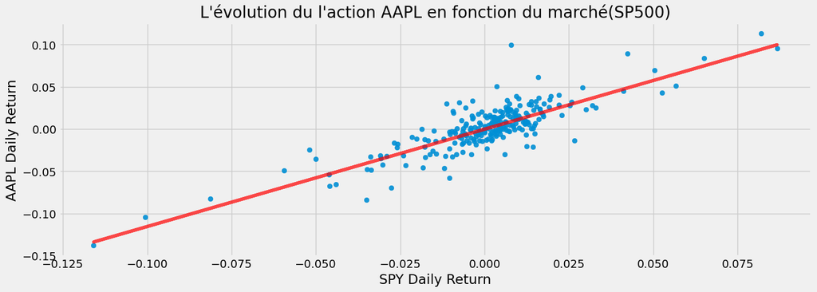

```python
Line1 = rf + (slope1*(test1.SPY - rf))
plt.figure(figsize=(15,5))
plt.scatter(test1.SPY,test1.AAPL, alpha=0.9)
plt.xlabel("SPY Daily Return")
plt.ylabel("AAPL Daily Return")
plt.plot(test1.SPY, Line1, 'r',alpha=0.7)
plt.title("L'évolution du l'action AAPL en fonction du marché(SP500)", size = 20)
plt.show()
```

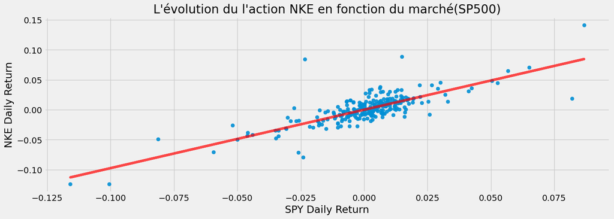

```python
Line2 = rf + (slope2*(test1.SPY - rf))
plt.figure(figsize=(15,5))
plt.scatter(test1.SPY,test1.NKE, alpha=0.9)
plt.xlabel("SPY Daily Return")
plt.ylabel("NKE Daily Return")
plt.plot(test1.SPY, Line2, 'r',alpha=0.7)
plt.title("L'évolution du l'action NKE en fonction du marché(SP500)", size = 20)
plt.show()
```

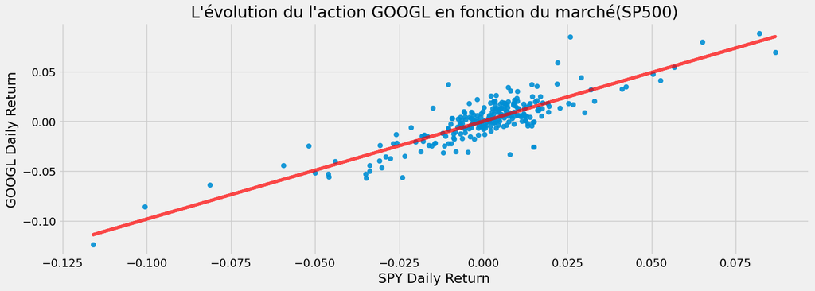

```python
Line3 = rf + (slope3*(test1.SPY - rf))
plt.figure(figsize=(15,5))
plt.scatter(test1.SPY,test1.GOOGL, alpha=0.9)
plt.xlabel("SPY Daily Return")
plt.ylabel("GOOGL Daily Return")
plt.plot(test1.SPY, Line3, 'r',alpha=0.7)
plt.title("L'évolution du l'action GOOGL en fonction du marché(SP500)", size = 20)
plt.show()
```

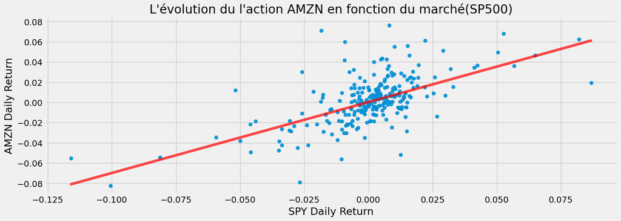

```python
Line4 = rf + (slope4*(test1.SPY - rf))
plt.figure(figsize=(15,5))
plt.scatter(test1.SPY,test1.AMZN, alpha=0.9)
plt.xlabel("SPY Daily Return")
plt.ylabel("AMZN Daily Return")
plt.plot(test1.SPY, Line4, 'r',alpha=0.7)
plt.title("L'évolution du l'action AMZN en fonction du marché(SP500)", size = 20)
plt.show()
```

### E- La Théorie Moderne du Portefeuille:

Avant d'appliquer le modèle à des milliers de portefeuilles aléatoires, démontrons les étapes sur un seul portefeuille. Et pour calculer le rendement et le risque du portefeuille (écart-type), nous aurons besoin de :

Les Rendement des actifs moyens

Le Poids du portefeuille

La Matrice de covariance de tous les actifs

Les Poids aléatoires des actifs

```python
def rand_weights(n):

    k = np.random.rand(n)
    return k / sum(k)
w=rand_weights(4)
w
```

```
array([0.04190012, 0.39493721, 0.37978544, 0.18337722])
```

- La variance du Portefeuille:

```python
cov_matrixN = test1[['AAPL','NKE','GOOGL','AMZN']].cov()
port_var = cov_matrixN.mul(w, axis=0).mul(w, axis=1).sum().sum()
port_var
```

```
0.0004673451159910786
```

```python
std_AAPL = assets['Volatility']['AAPL']
std_NKE = assets['Volatility']['NKE']
std_GOOGL = assets['Volatility']['GOOGL']
std_AMZN = assets['Volatility']['AMZN']
std_SPY = assets['Volatility']['SPY']
Var_Act = [math.pow(std_AAPL,2), math.pow(std_NKE,2), math.pow(std_GOOGL,2), math.pow(std_AMZN,2)]
β_Carre = [math.pow(slope1,2), math.pow(slope2,2), math.pow(slope3,2), math.pow(slope4,2)]
Rs = [i * math.pow(std_SPY,2) for i in β_Carre]
Rc = []
zip_object = zip(Var_Act, Rs)
for list1_i, list2_i in zip_object:
    Rc.append(list1_i-list2_i)
Risque = {'Action':['AAPL','NKE','GOOGL','AMZN'],
    'Risque Total':Var_Act,
    'Risque Systématique':Rs,

    'Risque Spécifique':Rc}
```

- Le risque systématique et spécifique de Portefeuille:

```python
β_Act = [slope1, slope2, slope3, slope4]
w_β = sum([a * b for a, b in zip(w, β_Act)])
Rs_P = math.pow(w_β,2)*math.pow(std_SPY,2)
Rc_P = port_var - Rs_P
Risque_P = {'Risque Total du Portefeuille':[port_var],
'Risque Systématique du Portefeuille':[Rs_P],
'Risque Spécifique du Portefeuille':[Rc_P]}
pd.DataFrame(Risque_P)
```

|  | Risque Total du Portefeuille | Risque Systématique du Portefeuille | Risque Spécifique du Portefeuille |
| --- | --- | --- | --- |
| 0 | 0.000467 | 0.098948 | -0.098481 |

- Le rendement espéré de portefeuille:

```python
ind_erN = test1[['AAPL','NKE','GOOGL','AMZN']].mean()
port_er = (w*ind_erN).sum()
port_er
```

```
0.0016039075535010656
```

- Le modèle de Markowitz sur 5000 portefeuilles aléatoires:

```python
p_ret = []
p_vol = []
p_weights = []
num_assets = len(test1[['AAPL','NKE','GOOGL','AMZN']].columns)
num_portfolios = 5000
```

```python
for portfolio in range(num_portfolios):
    weights = np.random.random(num_assets)
    weights = weights/np.sum(weights)
    p_weights.append(weights)
    returns = np.dot(weights, ind_erN)
    p_ret.append(returns)
    var = cov_matrixN.mul(weights, axis=0).mul(weights, axis=1).sum().sum()
    sd = np.sqrt(var)
    ann_sd = sd*np.sqrt(250)
    p_vol.append(ann_sd)
```

```python
w = rand_weights(4)
data = {'Returns':p_ret, 'Volatility':p_vol}
for counter, symbol in enumerate(test1[['AAPL','NKE','GOOGL','AMZN']].columns.tolist()):
    #print(counter, symbol)
    data[symbol+' weight'] = [w[counter] for w in p_weights]
    portfolios = pd.DataFrame(data)
    portfolios
```

- la frontière efficiente des portefeuilles aléatoires:

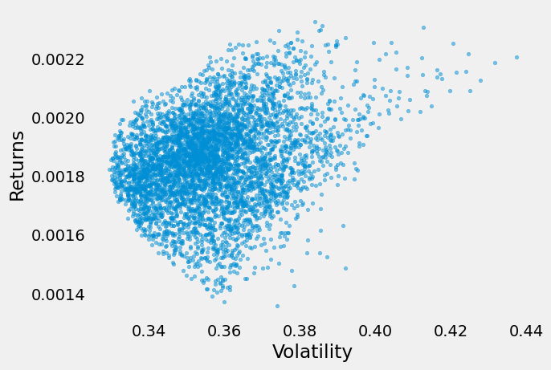

```python
portfolios.plot.scatter(x='Volatility', y='Returns', marker='o', s=10, alpha=0.5 , grid=False)
```

- Le Portefeuille à variance minimale:

```python
min_vol_port = portfolios.iloc[portfolios['Volatility'].idxmin()]
min_vol_port
```

```
Returns         0.001824
Volatility      0.329573
AAPL weight     0.001392
NKE weight      0.382195
GOOGL weight    0.178162
AMZN weight     0.438251
Name: 3922, dtype: float64
```

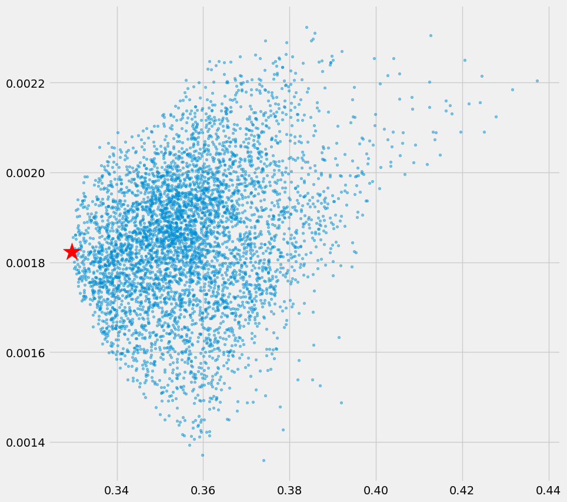

```python
plt.subplots(figsize=[10,10])
plt.scatter(portfolios['Volatility'], portfolios['Returns'],marker='o', s=10, alpha=0.5)
plt.scatter(min_vol_port[1], min_vol_port[0], color='r', marker='*', s=500)
```

- Le Portefeuille Optimal:

```python
rf = 0.001 # le taux sans risque
optimal_risky_port = portfolios.iloc[((portfolios['Returns']-rf)/portfolios['Volatility']).idxmax()]
optimal_risky_port
```

```
Returns         0.002294
Volatility      0.374424
AAPL weight     0.157058
NKE weight      0.002395
GOOGL weight    0.035165
AMZN weight     0.805382
Name: 1185, dtype: float64
```

- Le ratio de Sharpe de portefeuille optimale:

```python
(optimal_risky_port[0]-rf)/optimal_risky_port[1]
```

```
0.0034558304437123824
```

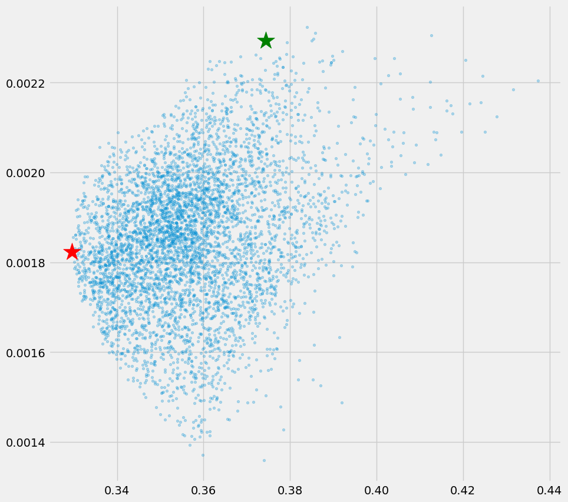

```python
plt.subplots(figsize=(10, 10))
plt.scatter(portfolios['Volatility'], portfolios['Returns'],marker='o', s=10, alpha=0.3)
plt.scatter(min_vol_port[1], min_vol_port[0], color='r', marker='*', s=500)
plt.scatter(optimal_risky_port[1], optimal_risky_port[0], color='g', marker='*', s=500)
```